# General Social Survey

Diego Martinez

7/5/22

# 1 Question 1

The data in the dataframe GSSdata is from the 2018 General Social Survey. The first blocks of R-code has selected down a subset of the data to just 16 variables. It has further removed unwanted factor levels in much of the data. Examine the code in the GrabData.R file to see what it is doing. Some of the variables are categorical and others are numerical. Be sure to do a variable analysis before tackling each question.  
First question - Is opinion on the death penalty (CAPPUN) independent of gun ownership (OWNGUN)?

$H_0$: There is no relationship between the opinion of death penalty & gun ownership. They are independent.

$H_A$: There is a relationship between the opinion of death penalty & gun ownership. They are dependent.

## 1.1 Methods

They’re both categorical variables with 2 levels. Thus, we will use a chi-squared test of independence and a fisher exact test for odds ratio. OWNGUN has YES/NO. CAPPUN has YES/NO.

## 1.2 Results

### 1.2.1 Descriptive Results

#### 1.2.1.1 Graphical Descriptive Results

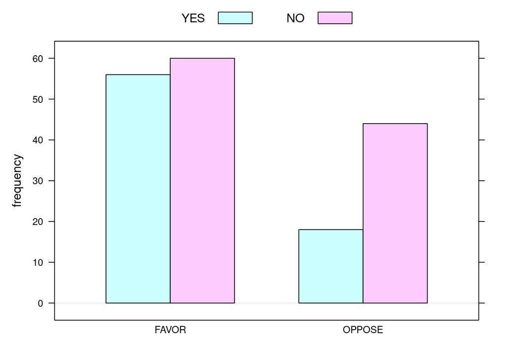

```r
barchartGC(~CAPPUN + OWNGUN,data=GSSdata)
```

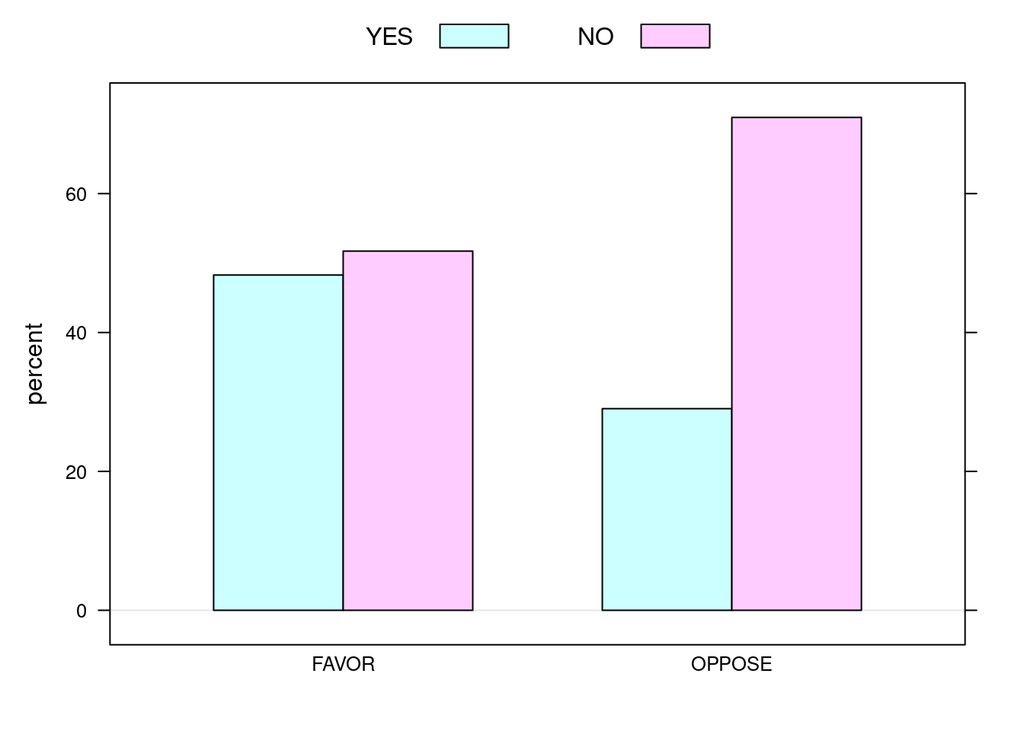

```r
barchartGC(~CAPPUN + OWNGUN,data=GSSdata, type="percent")
```

#### 1.2.1.2 Numerical Descriptive Results

```r
table1 <- xtabs(~CAPPUN + OWNGUN, data=GSSdata)
rowPerc(table1)
```

```
##         OWNGUN
## CAPPUN      YES     NO  Total
##   FAVOR   48.28  51.72 100.00
##   OPPOSE  29.03  70.97 100.00
```

```r
colPerc(table1)
```

```
##         OWNGUN
## CAPPUN      YES     NO
##   FAVOR   75.68  57.69
##   OPPOSE  24.32  42.31
##   Total  100.00 100.00
```

This table shows that if you believe in capital punishment you are likely not in favor of either yes or no. If you are oppose of capital punishment you are likely to say no 71% of the time. This table shows that if you believe in owning a gun you are likely to say yes 18% more of the time. If you are against owning a gun you are 18% more likely to say no.